# Primer paso: Decision Tree

Alejandro Bolaños

2018-08-26

> “We don’t want to focus on the trees (or their leaves) at the expense of the forest.” — Douglas R. Hofstadter

En este apartado repasaremos concepto ya aprendidos en materias anterior y los aplicaremos en nuestro problema.

Para refrescar el funcionamiento de los árboles de decisión, miremos el sitio [R2D3](http://www.r2d3.us/), los apartados:

- [Part 1: A Decision Tree](http://www.r2d3.us/visual-intro-to-machine-learning-part-1/)
- [Part 2: Bias and Variance](http://www.r2d3.us/visual-intro-to-machine-learning-part-2/)

#### Preguntas

- ¿Recuerda la proporción de `BAJA+2` presente?
- ¿En que puede afectar este desbalanceo al algoritmo?

```r
rm( list=ls() )
gc()
```

Empecemos trabajando con el primer árbol y veamos la salida del mismo. Empezamos a trabajar sobre el mes de `Febrero` (recordando de la clase anterior, que el mismo presentaba sus anomalías)

```r
library( "data.table" )
febrero  <-  fread("../datasets/201902.txt", header=TRUE, sep="\t")

library(rpart)
library( "rpart.plot" )

modelo   <-  rpart( clase_ternaria ~ .,   data = febrero,   cp=0.005,  xval=0 )
```

Veamos el modelo que nos devolvió:

```r
summary(modelo)
```

```
## Call:
## rpart(formula = clase_ternaria ~ ., data = febrero, cp = 0.005,
##     xval = 0)
##   n= 187861
##
##           CP nsplit rel error
## 1 0.05161602      0 1.0000000
## 2 0.01575816      2 0.8967680
## 3 0.01061264      5 0.8494935
## 4 0.00988905      6 0.8388808
## 5 0.00500000      8 0.8191027
##
## Variable importance
##               ttarjeta_visa          Visa_cuenta_estado
##                          27                          19
##              mcuentas_saldo   Visa_mfinanciacion_limite
##                          10                          10
##   mcuenta_corriente_Paquete ctarjeta_visa_transacciones
##                           7                           6
##       mtarjeta_visa_consumo      marketing_coss_selling
##                           6                           3
##    mdescubierto_preacordado                    internet
##                           2                           2
##   mcomisiones_mantenimiento           Visa_Fvencimiento
##                           1                           1
##        mcaja_ahorro_dolares  tmovimientos_ultimos90dias
##                           1                           1
##
## Node number 1: 187861 observations,    complexity param=0.05161602
##   predicted class=CONTINUA  expected loss=0.01103475  P(node) =1
##     class counts:   988  1085 185788
##    probabilities: 0.005 0.006 0.989
##   left son=2 (7725 obs) right son=3 (180136 obs)
##   Primary splits:
##       Visa_cuenta_estado          < 10.5      to the right, improve=531.8215, (6297 missing)
##       Master_cuenta_estado        < 10.5      to the right, improve=410.8036, (22749 missing)
##       Visa_mfinanciacion_limite   < 167.895   to the left,  improve=285.0436, (6297 missing)
##       Master_mfinanciacion_limite < 368.55    to the left,  improve=198.8961, (22749 missing)
##       mcuentas_saldo              < -66678.26 to the left,  improve=179.4206, (0 missing)
##   Surrogate splits:
```

[output cut: 158 more lines]

```
##       cprestamos_personales              < 0.5       to the right, agree=0.810, adj=0.254, (0 split)
##       mprestamos_personales              < 492.555   to the right, agree=0.810, adj=0.254, (0 split)
##       tseguro_vida_mercado_abierto       < 0.5       to the right, agree=0.810, adj=0.254, (0 split)
##       mttarjeta_visa_debitos_automaticos < 262.195   to the right, agree=0.781, adj=0.143, (0 split)
##       ttarjeta_visa_debitos_automaticos  < 0.5       to the right, agree=0.777, adj=0.127, (0 split)
##
## Node number 162: 63 observations
##   predicted class=BAJA+1    expected loss=0.4444444  P(node) =0.0003353543
##     class counts:    35    12    16
##    probabilities: 0.556 0.190 0.254
##
## Node number 163: 184 observations
##   predicted class=BAJA+2    expected loss=0.4836957  P(node) =0.0009794476
##     class counts:    54    95    35
##    probabilities: 0.293 0.516 0.190
```

Muchos datos, veamoslo un poco más reducido:

```r
modelo
```

```
## n= 187861
##
## node), split, n, loss, yval, (yprob)
##       * denotes terminal node
##
##   1) root 187861 2073 CONTINUA (0.005259208 0.005775547 0.988965246)
##     2) Visa_cuenta_estado>=10.5 7725 1197 CONTINUA (0.097216828 0.057734628 0.845048544)
##       4) ttarjeta_visa>=0.5 268   27 BAJA+1 (0.899253731 0.000000000 0.100746269)
##         8) internet< 0.5 244    4 BAJA+1 (0.983606557 0.000000000 0.016393443) *
##         9) internet>=0.5 24    1 CONTINUA (0.041666667 0.000000000 0.958333333) *
##       5) ttarjeta_visa< 0.5 7457  956 CONTINUA (0.068392115 0.059809575 0.871798310)
##        10) mcuentas_saldo< -8396.58 764  435 CONTINUA (0.310209424 0.259162304 0.430628272)
##          20) mdescubierto_preacordado< 0.585 569  352 BAJA+1 (0.381370826 0.323374341 0.295254833)
##            40) internet< 0.5 375  202 BAJA+1 (0.461333333 0.338666667 0.200000000)
##              80) ccomisiones_mantenimiento>=0.5 128   44 BAJA+1 (0.656250000 0.156250000 0.187500000) *
##              81) ccomisiones_mantenimiento< 0.5 247  140 BAJA+2 (0.360323887 0.433198381 0.206477733)
##               162) marketing_coss_selling>=5.5 63   28 BAJA+1 (0.555555556 0.190476190 0.253968254) *
##               163) marketing_coss_selling< 5.5 184   89 BAJA+2 (0.293478261 0.516304348 0.190217391) *
##            41) internet>=0.5 194  101 CONTINUA (0.226804124 0.293814433 0.479381443) *
##          21) mdescubierto_preacordado>=0.585 195   34 CONTINUA (0.102564103 0.071794872 0.825641026) *
##        11) mcuentas_saldo>=-8396.58 6693  521 CONTINUA (0.040788884 0.037053638 0.922157478) *
##     3) Visa_cuenta_estado< 10.5 180136  876 CONTINUA (0.001315673 0.003547320 0.995137008) *
```

Sería muy tentador poder jugar con los datos del modelo, por esto mismo, vamos a pasar el modelo a una tabla sobre la que podamos jugar. Construimos la siguiente función, y entendemos por la *dura* experiencia, que R, no es el lenguaje más lindo para escribir facilmente código. (maldigo la invención de los rownames!)

```r
table_rules <- function (model, ds, target) {


  # Tomamos la columna con el target
  target_vector <- ds[, get(target)]
  # Tomamos las clases de nuestro target
  classes <- unique(target_vector)

  # Tomamos las posicion de las reglas que aplican a los registro de nuestro ds,
  # y obtenemos las reglas

  row_leaf <- unique(model$where)
  row_name_leaf <- as.integer(rownames(model$frame[row_leaf,]))
  rules <- path.rpart(model, row_name_leaf, pretty = 0, print.it=FALSE)
  rules_concat <- lapply(rules,
                         function(y) paste0(tail(y, n=-1), collapse = " & "))
  leaves <- data.table(row_frame = row_leaf,
                       rules = rules_concat)
  setkey(leaves,row_frame)

  # Relacion target ~ hojas
  leaves_target <- dcast(

    data.table(
      target=target_vector,
      leaf = model$where),

    leaf ~ target, length,
    value.var = "target")

  setkey(leaves_target, leaf)

  # Juntamos todo
  leaves_target <- leaves_target[leaves,nomatch=0]

  # Sumamos algunas columnas calculadas
  colnames(leaves_target[,classes,with=FALSE])[apply(leaves_target[,classes,with=FALSE],1,which.max)]
  # Clase mayoritaria
  leaves_target[,
                y:=colnames(
                    leaves_target[,classes,with=FALSE]
                  )[
                    apply(leaves_target[,classes,with=FALSE],1,which.max)]
                ]

  # Cantidad clase mayoritaria
  leaves_target[, y_n:=unlist(apply(leaves_target[,classes,with=FALSE],1,max))]
  # Cantidad de elementos de la hoja
  leaves_target[, n := unlist(Reduce(function(a,b) Map(`+`,a,b), .SD)), .SDcols=classes]
  # Perdida
  leaves_target[, loss := n - y_n]

  # Return
  leaves_target
}
```

Aplicamos nuestra función a los datos generados:

```r
resultados <- table_rules(modelo, febrero, "clase_ternaria")
resultados
# View(resultados) # No siempre visualiza las reglas por ser un string largo.
```

Vemos que el algoritmos sólo eligió en una hoja la clase `BAJA+2`.

Calculemos la ganancia que tiene cada rama. Recuerde 19500 por cada `BAJA+2` y -500 por el resto.

```r
resultados[, ganancia:= `BAJA+2`*19500 - 500*(CONTINUA + `BAJA+1`)]

resultados
```

| leaf | BAJA+1 | BAJA+2 | CONTINUA | rules | y | y_n | n | loss | ganancia |
| --- | --- | --- | --- | --- | --- | --- | --- | --- | --- |
| 4 | 240 | 0 | 4 |  | BAJA+1 | 240 | 244 | 4 | -122000 |
| 5 | 1 | 0 | 23 |  | CONTINUA | 23 | 24 | 1 | -12000 |
| 10 | 84 | 20 | 24 |  | BAJA+1 | 84 | 128 | 44 | 336000 |
| 12 | 35 | 12 | 16 |  | BAJA+1 | 35 | 63 | 28 | 208500 |
| 13 | 54 | 95 | 35 |  | BAJA+2 | 95 | 184 | 89 | 1808000 |
| 14 | 44 | 57 | 93 |  | CONTINUA | 93 | 194 | 101 | 1043000 |
| 15 | 20 | 14 | 161 |  | CONTINUA | 161 | 195 | 34 | 182500 |
| 16 | 273 | 248 | 6172 |  | CONTINUA | 6172 | 6693 | 521 | 1613500 |
| 17 | 237 | 639 | 179260 |  | CONTINUA | 179260 | 180136 | 876 | -77288000 |

Si hicieramos caso a las clases del árbol, tendríamos una ganancia de:

```r
resultados[y == "BAJA+2", .(ganancia=sum(ganancia), enviados=sum(n), sevan=sum(`BAJA+2`))]
```

| ganancia | enviados | sevan |
| --- | --- | --- |
| 1808000 | 184 | 95 |

Pero, si tomamos todas las ramas que nos dieron ganancia positiva:

```r
resultados[ganancia > 0, .(ganancia=sum(ganancia), enviados=sum(n), sevan=sum(`BAJA+2`))]
```

| ganancia | enviados | sevan |
| --- | --- | --- |
| 5191500 | 7457 | 446 |

Wow!! Estabamos dejando mucho plata sobre la mesa! Veamos cómo clasificó a las hojas que nos dan ganancia positiva:

```r
resultados[ganancia > 0, .N, by=y]
```

| y | N |
| --- | --- |
| BAJA+1 | 2 |
| BAJA+2 | 1 |
| CONTINUA | 3 |

Listo, no podemos confiar en la clase, tenemos que avanzar por otro camino!

Entendemos que la diferencia se debe a la cantidad de casos en cada nodo y la proporción de `BAJA+2` en cada hoja.Vamos a trabajar con una nueva clase, una binaria:

`BAJA+2` = evento `BAJA+1` o CONTINUA = noevento

Para identificar las probabilidades de `BAJA+2` en forma directa:

```r
febrero[, clase_binaria := ifelse(clase_ternaria == "BAJA+2", "evento", "noevento")]

# Sacamos la clase ternaria
febrero[, clase_ternaria:= NULL]

modelo2   <-  rpart( clase_binaria ~ .,   data = febrero,   cp=0.005,  xval=0 )
modelo2
```

```
## n= 187861
##
## node), split, n, loss, yval, (yprob)
##       * denotes terminal node
##
## 1) root 187861 1085 noevento (0.005775547 0.994224453) *
```

Apa! No nos abre el árbol!!Esto se debe a los parámetros que le pasamos, la complejidad es muy alta. Veremos en otra clase las parametría del árbol, ahora simplemente bajaremos el parámetro *cp* y con esto obtendremos un árbol que separe las clases.

```r
modelo2   <-  rpart( clase_binaria ~ .,   data = febrero,   cp=0.001,  xval=0 )
```

Ahora aplicamos nuestra función para trabajar con los resultados:

```r
resultados2 <- table_rules(modelo2, febrero, "clase_binaria")
resultados2
```

Revisemos rápidamente la ganancia que obtenemos por clase *evento*

```r
resultados2[, ganancia:= evento*19500 - 500*noevento]
resultados2[y == "evento", .(ganancia=sum(ganancia), enviados=sum(n), sevan=sum(evento))]
```

| ganancia | enviados | sevan |
| --- | --- | --- |
| 3559000 | 242 | 184 |

La ganancia total si tomamos todos los nodos donde la misma es positiva:

```r
resultados2[ganancia > 0, .(ganancia=sum(ganancia), enviados=sum(n), sevan=sum(evento))]
```

| ganancia | enviados | sevan |
| --- | --- | --- |
| 7643000 | 4474 | 494 |

Upa! Subió mucho la ganancia, pronto tendremos que controlar el *overfitting*, pero no ahora. veamos a que tipo de clases pertenece esa ganancia:

```r
resultados2[ganancia > 0, .(n=.N, gan=sum(ganancia)), by=y]
```

| y | n | gan |
| --- | --- | --- |
| evento | 19 | 3559000 |
| noevento | 27 | 4084000 |

Ya no sosteniendo más esta forma de trabajar, vamos a calcular las probabilidades por hoja de que se vaya en 2 meses un cliente.

```r
resultados2[, c("p_evento","p_noevento"):= list(evento/n, noevento/n) ]
resultados2
```

| leaf | evento | noevento | rules | y | y_n | n | loss | ganancia | p_evento | p_noevento |
| --- | --- | --- | --- | --- | --- | --- | --- | --- | --- | --- |
| 11 | 39 | 6 |  | evento | 39 | 45 | 6 | 757500 | 0.866666667 | 0.1333333 |
| 13 | 14 | 2 |  | evento | 14 | 16 | 2 | 272000 | 0.875000000 | 0.1250000 |
| 14 | 4 | 8 |  | noevento | 8 | 12 | 4 | 74000 | 0.333333333 | 0.6666667 |
| 15 | 4 | 10 |  | noevento | 10 | 14 | 4 | 73000 | 0.285714286 | 0.7142857 |
| 17 | 8 | 3 |  | evento | 8 | 11 | 3 | 154500 | 0.727272727 | 0.2727273 |
| 19 | 6 | 2 |  | evento | 6 | 8 | 2 | 116000 | 0.750000000 | 0.2500000 |
| 21 | 7 | 10 |  | noevento | 10 | 17 | 7 | 131500 | 0.411764706 | 0.5882353 |
| 23 | 16 | 10 |  | evento | 16 | 26 | 10 | 307000 | 0.615384615 | 0.3846154 |
| 24 | 5 | 21 |  | noevento | 21 | 26 | 5 | 87000 | 0.192307692 | 0.8076923 |
| 26 | 7 | 4 |  | evento | 7 | 11 | 4 | 134500 | 0.636363636 | 0.3636364 |

[output cut: 45 more lines]

Graficamos para darnos una idea sobre la distribución de las probabilidades:

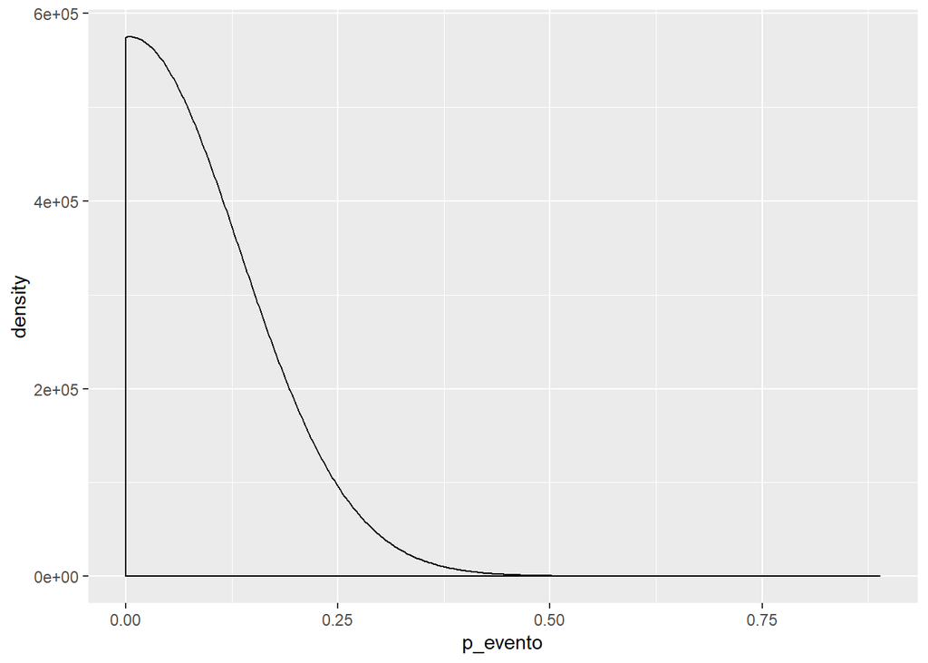

```r
library(ggplot2)

ggplot(resultados2, aes(x=p_evento)) +
     geom_density(aes(weights=y_n))
```

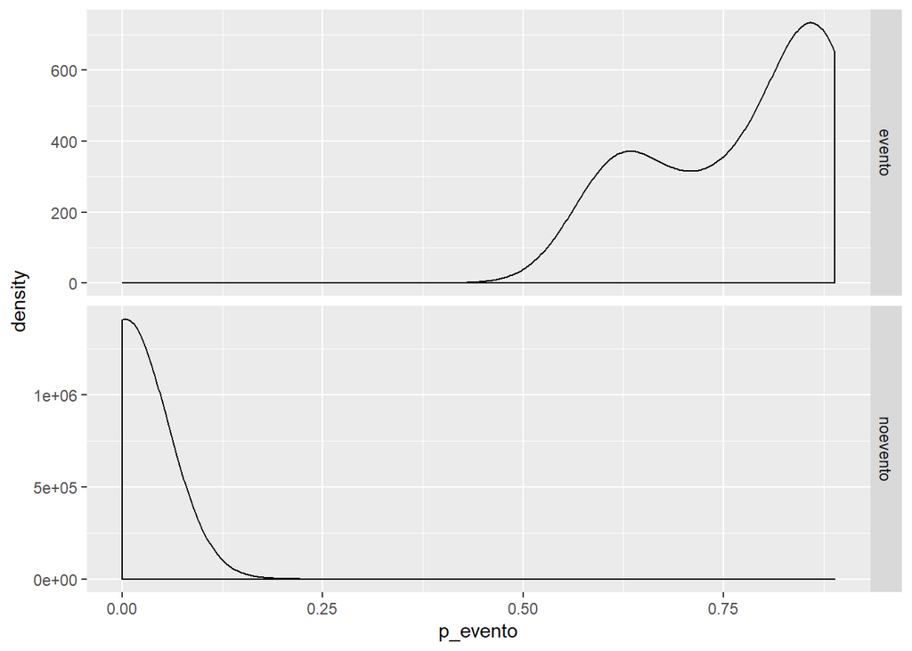

```r
ggplot(resultados2, aes(x=p_evento)) +
    facet_grid(vars(y), scales = "free_y") +
     geom_density(aes(weights=y_n))
```

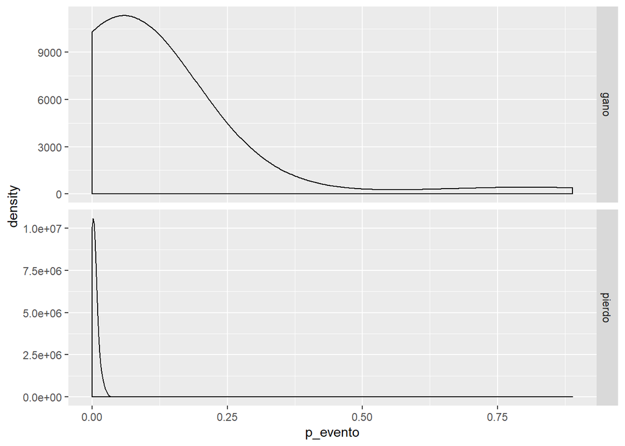

```r
resultados2[, gano := ifelse(ganancia > 0, "gano", "pierdo")]


ggplot(resultados2, aes(x=p_evento)) +
    facet_grid(vars(gano), scales = "free_y") +
     geom_density(aes(weights=y_n))
```

```r
# Una simple curiosidad...
weighted.mean(resultados2$p_evento, resultados2$y_n)
```

```
## [1] 0.005342233
```

¿Qué interpreta de estas densidades?

Definimos `punto de corte` a la probabilidad mínima que tiene que tener un elemento sobre esa clase para considerarla de la misma. Mirando el gráfico anterior, ¿qué punto de corte sugiere?